# Diplomado en Inteligencia Artificial y Aprendizaje Profundo

# Variables Aleatorias

## Profesores

1. Alvaro Mauricio Montenegro Díaz, ammontenegrod@unal.edu.co
2. Daniel Mauricio Montenegro Reyes, dextronomo@gmail.com
3. Campo Elías Pardo Turriago, cepardot@unal.edu.co

## Asesora Medios y Marketing digital

1. Maria del Pilar Montenegro, pmontenegro88@gmail.com

## Asistentes

1. Oleg Jarma, ojarmam@unal.edu.co
2. Laura Lizarazo, ljlizarazore@unal.edu.co

## Contenido

- Introducción
- Ejemplo de los dados
- Variable aleatoria
- Cálculo de frecuencias
- Función de Probabilidad de una variable numérica discreta
- Interpretación de la función de probabilidad
- Ejemplos de variables numéricas discretas
- Variable categóricas
- Esperanza Matemática de una variable aleatoria numérica
- Varianza y desviación estándar de una variable aleatoria
- Entropía de una variable aleatoria

## Introducción

En esta lección se introducen conceptos básicos de variables aleatorias, funciones de probabilidad y distribución acumulada.

## Ejemplo de los dados

Recordemos el ejercicio de la lección anterior Conceptos básicos. La imagen muestra do dados de seis caras de distinto color.

[figure not shown]

Dos datos de seis caras

Como ya sabe del ejercicio hay 36 posibles resultados. Es decir el espacio muestral $\mathcal{M}$ tiene 36 elementos y $2^{36}$ eventos.

Supongamos que $(x,y)$ es un elemento de $\mathcal{M}$. Observe que $(x,y)$ es en realidad una pareja de números. Por ejemplo $(3,4)$. Definamos ahora la siguiente función:

$$ f(x,y) = x+y, $$

es decir la función $f$ simplemente calcula la suma de los dos números. Como el espacio muestral tiene 36 elementos, entonces hay 36 posibles resultados, aunque no todos son diferentes.

La función $f$ se llama una **variable aleatoria**. Veámos algunos posibles valores que puede tomar la función:

$$ \begin{align} f(1,1) & = 2\\ f(3,2) & = 5\\ f(4,3) & = 7\\ f(3,4) & = 7\\ f(6,5) & = 11 \end{align} $$

## Variable aleatoria

Dado un espacio muestral $\mathcal{M}$, es una función que asigna a los elementos del espacio muestral un número real.

En el espacio muestral de los dos dados de seis lados, se pueden definir muchas variables aleatorias. Considere por ejemplo la variable aleatoria definida por $g(x,y) = x\times y$.

### Ejercicio

Considere el ejemplo del espacio muestral de los dos dados de seis caras, no cargados.

1. Construya la tabla completa de los posibles resultados de de las funcioens $f$ y $g$.
2. Proponga otra variable aleatoria definida sobre el espacio muestral $\mathcal{M}$.

Ayuda: Use Python. Construya primero la tabla que representa el espacio muestral, en un tensor $36\times 2$. En otro tensor construya los respectivos valores de la función.

```python
# Ayuda (que el profesor no se cuenta)
import numpy as np


# espacio muestral
M = np.zeros((36,2))
k = 0
for i in range(1,7):
    for j in range(1,7):
        M[k,] = (i,j)
        k+=1


# calcula la variable aleatoria f: f(x,y)=x+y
f = np.zeros(36)
for k in range(36):
    f[k] = M[k,0] + M[k,1]


# presenta los resultados
for k in range(36):
    print('f(',M[k,0],',',M[k,1],') =', f[k])
```

```
f( 1.0 , 1.0 ) = 2.0
f( 1.0 , 2.0 ) = 3.0
f( 1.0 , 3.0 ) = 4.0
f( 1.0 , 4.0 ) = 5.0
f( 1.0 , 5.0 ) = 6.0
f( 1.0 , 6.0 ) = 7.0
f( 2.0 , 1.0 ) = 3.0
f( 2.0 , 2.0 ) = 4.0
f( 2.0 , 3.0 ) = 5.0
f( 2.0 , 4.0 ) = 6.0
f( 2.0 , 5.0 ) = 7.0
f( 2.0 , 6.0 ) = 8.0
f( 3.0 , 1.0 ) = 4.0
f( 3.0 , 2.0 ) = 5.0
f( 3.0 , 3.0 ) = 6.0
f( 3.0 , 4.0 ) = 7.0
f( 3.0 , 5.0 ) = 8.0
f( 3.0 , 6.0 ) = 9.0
f( 4.0 , 1.0 ) = 5.0
f( 4.0 , 2.0 ) = 6.0
f( 4.0 , 3.0 ) = 7.0
f( 4.0 , 4.0 ) = 8.0
f( 4.0 , 5.0 ) = 9.0
f( 4.0 , 6.0 ) = 10.0
f( 5.0 , 1.0 ) = 6.0
f( 5.0 , 2.0 ) = 7.0
f( 5.0 , 3.0 ) = 8.0
f( 5.0 , 4.0 ) = 9.0
f( 5.0 , 5.0 ) = 10.0
f( 5.0 , 6.0 ) = 11.0
f( 6.0 , 1.0 ) = 7.0
f( 6.0 , 2.0 ) = 8.0
f( 6.0 , 3.0 ) = 9.0
f( 6.0 , 4.0 ) = 10.0
f( 6.0 , 5.0 ) = 11.0
f( 6.0 , 6.0 ) = 12.0
```

## Cálculo de frecuencias

Observe que en el ejemplo anterior, la variable aleatoria toma once(11) posibles valores diferentes:

$$f=\{ 2,3,4,5,6,7,8,9,10,11,12\}$$

.

Entonces tenemos lo siguiente: 36 posibles valores, pero solamente 11 diferentes. El siguiente fragmento de código muestra como obtener los posibles valores diferentes que toma la variable aleatoria $f$.

```python
print(np.unique(f))
```

```
[ 2.  3.  4.  5.  6.  7.  8.  9. 10. 11. 12.]
```

### Función Python para calcular una tabla de frecuencias

La siguiente función muestra un camino de como calcular la tabla de frecuencias de un conjunto de datos, puestos en una lista de Python. No es la única forma. Investigue otras formas de hacerlo.

```python
# Función Python para contar los elementos la fecuencia
# de los elementos de una lista, usando un diccionario

def CountFrequency(my_list):

    # Creating an empty dictionary
    freq = {}
    for item in my_list:
        if (item in freq):
            freq[item] += 1
        else:
            freq[item] = 1
    return freq
```

Asegúrese de entender completamente el código. Vamos a probar la función con dos ejemplos. Primero calculamos la frecuencia de los valores de la variable aleatoria $f$.

```python
frec = CountFrequency(f)

for key, value in frec.items():
    print ("% d : % d"%(key, value))

frec
```

```
 2 :  1
 3 :  2
 4 :  3
 5 :  4
 6 :  5
 7 :  6
 8 :  5
 9 :  4
 10 :  3
 11 :  2
 12 :  1
```

```
{2.0: 1,
 3.0: 2,
 4.0: 3,
 5.0: 4,
 6.0: 5,
 7.0: 6,
 8.0: 5,
 9.0: 4,
 10.0: 3,
 11.0: 2,
 12.0: 1}
```

Podemos manipular directamente los valores del diccionario. Por ejemplo para calcular la frcuencia de 7, que ya sabemos es 6, se escribe

```python
frec[7]
```

```
6
```

En un segundo ejemplo, consideremos el conjunto $ W= \{A,B,B,C,A,A \}$

```python
W = ['A','B','B','C','A','A']
frec = CountFrequency(W)
frec['B']
```

```
2
```

## Función de Probabilidad de una variable numérica discreta

Ahora que hemos aprendido a calcular tablas de frecuencias de conjuntos de datos organizados en una lista, vamos a introducir el concepto clave de función de probabilidad. En esta sección consideramos variables aleatorias numérica discreta como la función $f$ asociada al espacio muestral del lanzamiento de dos dados no cargados. En la siguiente sección consideramos variables categóricas y en otra lección consideramos variables contínuas.

Como observamos antes, la variable aleatoria $f$ es discreta (particularmente es finita), debido a que toma únicamente 11 posibles valores numéricos. Por otro lado sabemos que el resultado del experimento de lanzar los dados puede arrojar 36 posibles resultados. La **función de probabilidad de la variable aleatoria** *f*, que notaremos $p_f$ se define como la probabilidad de obtener cada posible valor de *f*.

Entonces como vimos arriba tenemos que la función de probabilidad de la variable aleatoria $f$ esta definida por extensión de la siguiente forma:

$$ \begin{align} p_f[2] & = 1/36\\ p_f[3] & = 2/36\\ p_f[4] & = 3/36\\ p_f[5] & = 4/36\\ p_f[6] & = 5/36\\ p_f[7] & = 6/36\\ p_f[8] & = 5/36\\ p_f[9] & = 4/36\\ p_f[10] & = 3/36\\ p_f[11] & = 2/36\\ p_f[12] & = 1/36 \end{align} $$

Podemos obtener una imagen de la función, utlizando un histograma. Un histograma es un gráfico de una función de probabilidad de una variable numérica. El siguiente código Python mustra como construir un histograma de la variable aleatoria *f*.

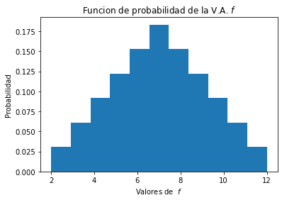

```python
import matplotlib.pyplot as plt
plt.hist(f, bins=11,density=True)
plt.title('Funcion de probabilidad de la V.A. $f$')
plt.xlabel('Valores de  $f$')
plt.ylabel('Probabilidad')
plt.show()
```

### Cálculo de algunas probabilidades

Dado que la variable aleatoria $f$ es númerica, podemos calcular la probabilidad de diferentes eventos del epacio muestral, basados en el valor de $f$. Veámos algunos ejemplos.

$$ \begin{align} \text{Prob}[f \text{ es par }] &= 18/36\\ \text{Prob}[f\le 6] &= 15/36\\ \text{Prob}[f> 10] &= 3/36\\ \text{Prob}[f \text{ es par }|f<5] &= 4/6 \end{align} $$

Por favor verifique estos resultados.

## Interpretación de la función de probabilidad

Supongamos que el experimento de lanzar se repite muchas veces. Digamos 100 veces. Como la probabilidad de obtener digmamos $f=7$ es $6/36$, entonces lo que se espera que ocurra es que en los 100 lanzamientos se obtenga un valor cercano a

$$ \text{Número de veces que se espera que ocurra }\{f=7\} = \tfrac{6}{36}\times 100 \approx 17. $$

Por supuesto, no necesariamente el resultado será 17. Pero si un número cercano. Por ejemplo no esperamos que no ocurra ninguna vez o que ocurra todas las veces el resultado $\{f=7\}$.

## Ejemplos de variables numéricas discretas

### Variable de Bernoulli (Distribución de Bernoulli)

Una variable aleatoria $f$ es Bernoulli, si solamente toma dos posibles valores, los cuales por convención son $\{0,1\}$. Es común llamar al resultado 1 como *exito* y a cero como *fallo*. Observe que en este caso se tiene que la función de probabilidad es dada por

$$ \begin{align} p_f[1] &= \pi\\ p_f[0] &= 1-\pi, \end{align} $$

en donde $\pi = \text{Prob}[f=1]$. En este caso, se puede escribir la función en una forma más compacta como

$$ p_f[x] = \pi^{x}(1-\pi)^{1-x}, \quad x=0,1. $$

Asegúrese de entender la fórmula anterior.

Un ejemplo es el siguiente. En el experimento del lanzamiento dados no cargados, definimos la variable aleatoria $g$ como sigue:

$$ g = \begin{cases} &1, \text{ si la suma de los dos dados es par} \\ &0, \text{ si la suma de los dos dados es impar} \end{cases} $$

Verifique que en este caso $\pi =18/36=1/2$.

### Variable Binomial (Distribución Binomial)

Consideremos la variable aleatoria $g$ definida arriba. Pero ahora vamos a considerar que hacemos el experimento digamos $N=3$ veces y contamos el número de veces en que $g=1$. Por otro lado vamos a suponer que que hay un sesgo en el experimento (una especie de dados cargados y se verifica que $\text{Prob}[g=1] = 0.6$. Por lo tanto se tiene que $\text{Prob}[g=0] = 0.4$.

Entonces obtenemos una variable aleatoria que llamaremos $q$ y diremos que $q$ es una variable Binomial. La función de probabilidad de la variable aleatoria $q$ es dada por extensión como sigue. La variable $q$ toma 4 posibles valores, $q = \{0,1,2,3\}$

Veámos como calcular las probabilidades de los valores de $q$. La siguiente tabla muestra como calcular tales probabilidades.

| Valor | Experimentos | probabilidad cada experimento | probabilidad para este valor de f | total |
| --- | --- | --- | --- | --- |
| 0 | 000 | $0.4\times 0.4 \times 0.4$ | 0.064 | 0.064 |
| 1 | 100 | $0.6\times 0.4 \times 0.4$ | 0.096 |  |
| 1 | 010 | $0.4 \times 0.6\times 0.4$ | 0.096 |  |
| 1 | 001 | $0.4 \times 0.4\times 0.6$ | 0.096 | 0.288 |
| 2 | 110 | $0.6\times 0.6 \times 0.4$ | 0.144 |  |
| 2 | 011 | $0.4 \times 0.6\times 0.6$ | 0.144 |  |
| 2 | 101 | $0.6 \times 0.4 \times 0.6$ | 0.144 | 0.432 |
| 3 | 111 | $0.6 \times 0.6\times 0.6$ | 0.216 | 0.216 |

Entonces se tienen que

$$ \begin{align} p_q[0] & = 0.064 \\ p_q[1] & = 0.288\\ p_q[2] & = 0.432\\ p_q[3] & = 0.216 \end{align} $$

#### Ejercicio

Verifique los cálculos de la tabla anterior y asegúrese de entender completamente.

El siguiente código muestra como calcular la función de probabilidad de la variable Binomial $q$ y como obtener un gráfico de la función.

```
p_q= [0.064 0.288 0.432 0.216]
```

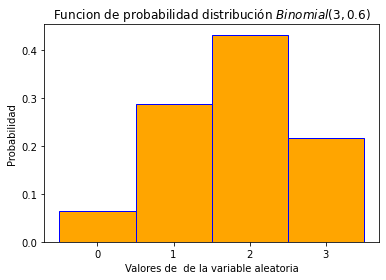

```python
import numpy as np
from scipy.stats import binom
import matplotlib.pyplot as plt

N, p  = 3, 0.6
p_q = np.zeros(4)

for k in range(4):
    p_q[k] = binom.pmf(k,N,p)

print('p_q=',p_q)
label = ['0','1','2','3']
plt.bar(label, p_q, color = 'orange', edgecolor='blue',width=1)
plt.title('Funcion de probabilidad distribución $Binomial(3,0.6)$')
plt.xlabel('Valores de  de la variable aleatoria')
plt.ylabel('Probabilidad')
plt.show()
```

Note que la función de probabilidad de Bernoulli es un caso especial de la Binomial con $N=1$.

Existe una formula general para la función de probabilidad de una variable Binomial. Si se supone que se hacen $N$ experimentos de Bernoulli realizados de manera independientes con la misma probabilidad de exito (obtener 1), y se anota el número de unos (*exitos*) obtenidos, entonces la probabilidad de obtener $k$ exitos es dada por

$$ p_{bin}[k] = \binom{N}{k}\pi^k(1-\pi)^{N-k}, $$

en donde $\binom{N}{k}$ es el símbolo combinatorio y $\pi$ es la probabilidad de exito de cada experimento de Bernoulli.

**Nota.**

Recuerde que el combinatorio $\binom{N}{k}$ es el número de grupos diferentes de tamaño *k* que se pueden formar teniendo *N* elementos. Consulte cualquier libro de probabilidad para los detalles matemáticos.

### Variable Poisson (Distribución de Poisson)

Esta distribución es utilizada en problemas de conteo. Por ejemplo el número de bacterias por unidad de área o volúmen encontradas en un cultivo microbiológico.

Una variable Poisson puede tomar teóricamente valores enteros entre cero e infinito. La función de probabilidad en este caso está dada por

$$ p_{poi}[k] = \frac{e^{\lambda}\lambda^k}{k!},\quad k=0,1, \ldots $$

El valor $\lambda$ se interpreta como la cantidad promedio de elementos encontrados por unidad de área, volúmem, etc.

#### Ejercicio

1. Revise en cualquier libro de probabilidad y estadística ejemplos de aplicación de la distiribución de Poisson.
2. Investigue como calcular probabilidades de la distribución de Poisson con scipy de Python. Suponga que para algún caso $\lambda = 5.3$. Calcule las probabilidades para $ k=0,1,\ldots, 20$. Haga un gráfico de la función de probabilidad con esos datos (obviamente es una aproximación de la función completa).
3. Haga sus comentarios.

**Consigne su solución aquí**

## Variable categóricas

En esta sección vamos a suponer que la variable aleatoria no asigna valores numéricos a los elementos del espacio muestral. En lugar de eso, asigna etiquetas. Usualmente dice que en este caso la variable es en realidad un objeto aleatorio. No haremos esa distinción en este desarrollo, pero si seremos cuidadosos en tener en cuenta que la variable no es numérica.

Por facilidad usaremos de nuevo el ejemplo de los dados no cargados. Definimos la siguiente variable aleatoria que llamaremos $X$. Para este ejercicio vamos a distinguir el color de los dados. Entonces en la pareja $(x,y)$, $x$ corresponde al valor del dado rojo. adicionalmente $y$ representa el valor del dado azul. Entonces

$$ X((x,y)) = \begin{cases} &R, \text{ si } x>y\\ &A, \text{ si } x<y\\ &B, \text{ si } x=y\\ \end{cases} $$

Observe que en realidad el color del dado es indiferente para la definición de la variable aleatoria

Entonces, la función de probabilidad en este caso es dada por

$$ \begin{align} p_X[R] &= \tfrac{15}{36}\\ p_X[A] &= \tfrac{15}{36}\\ p_X[B] &= \tfrac{6}{36}\\ \end{align} $$

Aún podemos hacer un gráfico de la función de probabilidad $p_X$ como sigue.

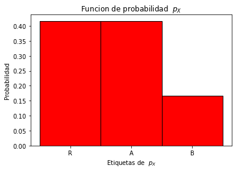

```python
import numpy as np
import matplotlib.pyplot as plt

p_X = np.array([15/36,15/36, 6/36])
label = ['R','A','B']

plt.bar(label,p_X, color = 'red', edgecolor='black',width=1)
plt.title('Funcion de probabilidad  $p_X$')
plt.xlabel('Etiquetas de  $p_X$')
plt.ylabel('Probabilidad')
plt.show()
```

Obviamente en este caso no hay cantidades numéricas, por lo que el gráfico puede obtenerse de distintas formas, cambiando el orden de la etiquetas. Sin embargo, aún podemos hacer algunos cálculos de probabilidad.

Por ejemplo, la probabilidad de obtener *R* o *A* es dada por $30/36$.

## Esperanza Matemática de una variable aleatoria numérica

La esperanza matemática de una variable aleatoria numérica discreta es el promedio ponderado de todos sus posibles valores. La ponderación como se puede sospechar es dada por la función de probabilidad de la variable.

La definición se basa en el hecho que la función de probabilidad de la variable aleatoria representa la frecuencia relativa teórica de cada resultado particular.

Se tiene que si $X=\{x_1,x_2,\ldots \}$ es el conjunto de valores de la variable aleatoria $X$ y si la función de probabilidad de $X$ es dada por $p_X =\{p_1, p_2,\ldots \}$, en donde $p_X[x_i] = p_i$, entonces la esperanza matemática de $X$ se denota por $\mathbb{E}[X]$ y es dada por

$$ \mathbb{E}[X] = p_1x_1 + p_2x_2 +\ldots = \sum_{i} p_ix_i $$

### Ejemplo

En el ejemplo de los dados se tiene que

$$ \mathbb{E}[f] = \tfrac{1}{36}[2\times 1 + 3\times 2 + 4\times 3 + 5 \times 4 + 6\times 5 + 7\times 6 +8\times 5 + 9\times 4 + 10 \times 3 + 11 \times 2 + 12 \times 1 ] = 7. $$

Puede tambien calcular la esperanza de $f$ con numpy como sigue.

```python
np.mean(f)
```

[output not shown]

### Esperanza de la distribución Binomial

En el caso del ejemplo binomial de la moneda cargada que se lanza tres veces tenomos que

$$ \mathbb{E}[f] = 0\times 0.064 + 1 \times 0.288 + 2 \times 0.432 + 3 \times 0.216= 1.8. $$

Se puede verificar que si una variable aleatoria $X$ tiene distribución (función de probabilidad) Binomial, $\text{Bin}(N,p)$, entonces

$$ \mathbb{E}[X] = Np. $$

Puede consultar cualquier texto de probabilidad para verificar el resultado. El siguiente código muestra como calcular la esperanza para el caso $\text{Bin}(3,0.6)$, con Python.

```python
from scipy.stats import binom
binom.expect(args=(3,0.6))
```

```
1.7999999999999998
```

### Ejercicio

De una interpretación al resultado anterior. Observe que 1.8 no corresponde a un valor que pueda tomar la variable aleatoria.

### Esperanza de la distribución Poisson

Una variable aleatoria con distribución $\text{Pois}(\lambda)$ tiene esperanza matemática $\lambda$.

### Ejercicio

Verifique la afirmación anterior.

## Varianza y desviación estándar de una variable aleatoria

La varianza de una variable aleatoria mide su nivel de predictibilidad. Dicho en otras palabras, que tan dispersos son los valores de la variable aleatoria en relación con la esperanza matemática. Denotemos la esperanza de $X$ por $\mu_X$. Técnicamente la varianza de una variable aleatoria se define por

$$ Var[X] = \mathbb{E}[X-\mu_X]^2 = \sum_{i}p_i (x_i- \mu_X)^2. $$

### Desviación estándar

La desviación estándar de una variable aleatoria se denota $\sigma_X$ y es simplemente la raíz cuadrada de la varianza, es decir,

$$ \sigma_X = \sqrt{Var[X]}. $$

Para entender el porque la varianza mide el nivel de predictibilidad de una variable aleatoria consideremos una variable Bernoulli $X$. Escribimos $X \sim \text{Ber}(\pi)$. En este caso puede verificarse que la varianza es dada por

$$ Var(X) = \pi(1-\pi). $$

El siguiente gráfico muestra la varianza de las distribuiciones Bernoulli con valorea distintos del parámetro $\pi$.

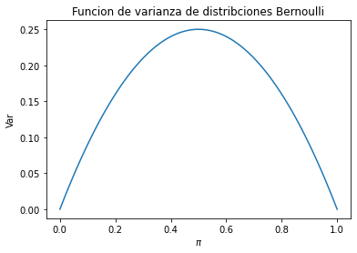

```python
import numpy as np
import matplotlib.pyplot as plt

pi = np.linspace(0,1,100)
var = pi*(1-pi)
plt.plot(pi,var)
plt.title('Funcion de varianza de distribciones Bernoulli')
plt.xlabel( '$\pi$')
plt.ylabel('Var')
plt.show()
```

Se observa entonces que la máxima varianza se alcanza para el caso $\pi=0.5$. Es porque en este caso, es mas difícil predecir el resultado del experimento, dado que la probabilidad de *acierto* y *fallo* son la misma. Pero a medida que el valor $\pi$ está cerca de cero o uno, la varianza desciende hasta cero. Por ejemplo si $\pi = 0.9$, casi siempre se obtendrá *exito*. Esto siginifica que la variable es más predictible para valores muy altos o muy bajos de $\pi$. **A menor varianza mayor precisión para predecir el resultado del experimento y viceversa**.

## Entropía de una variable aleatoria

Similar a la varianza, la entropia de una variable aleatoria mide su grado de predictibilidad desde el punto de vista de la teoría de información de Shanon. Dada una variable aleatoria discreta $X=\{x_1,x_2,\ldots \}$ con función de probabilidad $p_X =\{p_1, p_2,\ldots \}$, la entropia de $X$ se define por

$$ H(X) = -\sum_i p_i\log p_i = -\mathbb{E}[\log P_X] $$

Es usual utilizar la base 2 o la base de los logaritmos Neperianos. En el primer caso, la unidad de medida de la entropía de denomina bit. En el caso de los logaritmos Neperianos, la unidad de medida se acostumbra a llamar nat. En realidad pasar de una base a otra es simplemente un cambio de escala. Estructuralmente miden lo mismo en distintas unidades.

Como en el caso de la varianza ilustramos el concepto para el caso de la distribución Bernoulli.

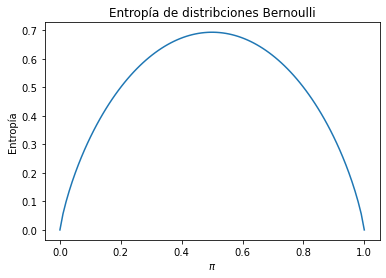

```python
import numpy as np
import matplotlib.pyplot as plt

pi = np.linspace(0.0000001,0.999999,100)
H = -(pi*np.log(pi) + (1-pi)*np.log(1-pi))
plt.plot(pi,H)
plt.title('Entropía de distribciones Bernoulli')
plt.xlabel( '$\pi$')
plt.ylabel('Entropía')
plt.show()
```

Como se observa la entropia mide de la misma forma que la varianza pero en una escala diferente. Por otro lado observe que en el cálculo de la entropia no se utilizan los valores que toma la variable aleatoria. Solamente se requiere la función de probabilidad de la variable.

En palabras se dice que **la entropía no depende de la escala de la variable**. Solamente de su estructura de probabilidad. Por su parte la varianza si es dependiente de la escala de la variable aleatoria.

- Regresar al inicio